# Evaluation Lead case study — cleaning and analyzing survey data

## Requirements

To effectively reproduce the process, the following packages are required in R:  
- [tidyverse](https://www.tidyverse.org/) — `install.packages("tidyverse")`  
- [dplyr](https://dplyr.tidyverse.org/) — `install.packages("dplyr")`  
- [ggplot2](https://ggplot2.tidyverse.org/) — `install.packages("ggplot2")`  
- [lubridate](https://cran.r-project.org/web/packages/lubridate/) — `install.packages("lubridate")`  
- [readr](https://readr.tidyverse.org/) — `install.packages("readr")`  
- knitr `conda install -c conda-forge r-knitr`  
- [rmarkdown](https://rmarkdown.rstudio.com/)

If you are working in visual studio code, you need to install the following extensions:  
- [Language Server](https://code.visualstudio.com/docs/languages/r) — `install.packages("languageserver")`  
- [R Lang](https://www.r-project.org/)

If you are working in visual studio code and want to use the jupyter notebook version of the codes, you need to install the following extensions in your environment:  
- [R Kernel](https://anaconda.org/r/r-irkernel) — `conda install -c r r-irkernel`

## Introduction

The evaluation lead case study constitutes a comprehensive skills assessment endeavor aimed at quantifying candidates’ proficiency in various domains, including:

- Proficiency in quantitative and qualitative data collection and analysis, with a particular emphasis on quantitative aptitude.
- Competence in conducting data analysis using R and other statistical programming languages.
- Proficiency in data visualization techniques using R and other statistical programming languages.
- Skill in monitoring data quality, carrying out data cleaning, coding, analysis, and succinctly reporting findings.
- Ability to effectively communicate results by crafting suitable information products.

The foundational data for this case study originates from a sample extracted from pre and post-surveys administered to a youth audience after they attended Jack Talks—a series of mental health presentations led by young individuals for their peers. These presentations leverage personal narratives and mental health education to inspire, engage, educate, and empower young audiences. The pre and post-surveys are instruments to gauge the impact of the Jack Talks presentations on the audience, providing a comprehensive framework for evaluation and analysis.

## Goal

The core objective of this project is to meticulously clean and conduct comprehensive analyses on both the pre and post-survey datasets. This analytical approach closely follows the provided instructions, establishing a succinct and replicable framework that allows for future scalability.

## Data

The project’s data can be accessed within the “datasets” directory. This data is structured as two separate CSV files: “CASE STUDY - Livestream pre FY23” and “CASE STUDY - Livestream post FY23”. Additionally, candidates have access to the data through the provided package. It’s important to note that the datasets are not hosted on GitHub due to the sensitivity of the data.

## Process

The project workflow encompasses the following sequential steps:

1. Import the data into the R environment.
2. Perform individualized data cleaning for each dataset.
3. Merge the cleaned datasets into a unified dataset.
4. Conduct comprehensive data analysis.
5. Present the results of the investigation.

For a detailed breakdown of each of these processes, you can refer to the provided instructions. These instructions are also accessible within the “instructions” folder.

In addition, the codebooks — “data_cleaning” and “data_analysis” serve as comprehensive documentation of the steps and methodologies employed throughout the project. They feature R code snippets and descriptive docstrings for seamless comprehension and traceability. Each code file comes in two formats — an R-markdown file and a Jupyter notebook file (you will need an IRkernel to run R codes in Jupyter notebook).

## Deliverables

The deliverables encompassed by this project include:

- A “report document” (This Markdown document)
- A spreadsheet of the “cleaned data set” in the form of a CSV file. You can locate this file in the `data_output` directory, named “final_df_numeric.csv”
- A “coding script” including annotations for each step in the process. The R Markdown versions are labeled “data_cleaning.rmd” and “data_analysis.rmd”. Additionally, IPython notebook versions are available in the `code` folder.
- Results for “requirements 5 and 6”, along with additional descriptions or notes essential for interpreting the project. These can be located in the `data_output` directory as “qn_5.csv” and “qn_6.csv”. This report provides comprehensive illustrations of these results, including data visuals for enhanced interpretability.

### Step 1: Data cleaning

The process and code for data cleaning are meticulously documented within the data_cleaning.rmd / data_cleaning.ipynb files within the code directory. The executed data cleaning process was designed to align the data with the seven distinct dimensions of data quality, as delineated below:

- Completeness - Reflects the extent to which all records possess anticipated data.
- Uniqueness - Pertains to the degree of non-duplication among records within the dataset.
- Timeliness - Conveys the degree of data’s currency and up-to-dateness.
- Validity - Quantifies the extent to which dataset records conform to valid data types.
- Accuracy - Measures data’s correctness and its fidelity in representing the truth.
- Consistency - Defines the allowable deviation between two datasets.
- Relevance - Gauges the data’s appropriateness for the required analysis.

#### 1.1 Asserting test for completeness, uniqueness, timeliness, and relevance.

Quality checks were systematically conducted and data was cleansed in a stepwise manner. As I progressed through the steps, I noticed a reduction in the number of quality violations. This observation suggests that the preceding steps effectively addressed most of the violations. After each cleaning iteration, quality control checks were exerted to ensure compliance. The cleaned datasets were exported to csvs that can be found in the data_output folder. The results are depicted in the table below.

[output not shown]

Observations

- After filtering out incomplete responses (2,878 incomplete and 582 with atleast 1 blank or NA), the pre-survey dataset consisted of 7,465 completed responses, indicating a completion rate of 68.3%. The pre-survey dataset contained a total of 10,925 records.
- The post survey contained a total of 6,856 records. After removing incomplete responses, the dataset comprised 3,518 valid responses, signifying a completion rate of 51.3%.  
  A visual depiction can be seen below.

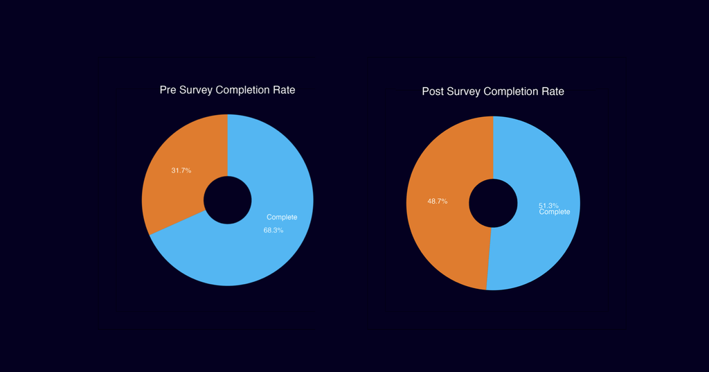

#### 1.2 Merging and exerting tests for validity, accuracy, and consistency.

The two datasets were merged for each same respondent using the “id” columns. The validity, accuracy, and consistency tests were systematically conducted. Data was cleaned using appropiate methods to ensure complaince. The outcome of the tests followed almost a simmilar pattern from the previous step. After each test-cleaning step, a quality control check was performed to ensure the data complies with the standards required. The results are depicted in the table below.

| Quality Dimension | Definition | Result |
| --- | --- | --- |
| Validity | Degree to which the records in a dataset are valid. | The quality assertion here is that post survey cannot be taken before the pre survey. There are at least 262 matching surveys where post-survey was taken before the pre survey by at least 1 day. |
| Accuracy | Degree to which the data is correct and represents the truth. | The assumption is that the data is correct and represents the truth. Further domain knowledge is required to validate accuracy. |
| Consistency | A threshold for how much difference there can be between two datasets. | There was a total of 6,978 records after merging, with only 2,606 matching records. 4,372 records failed this test. |

Observations

- A minimum of 262 instances of matching surveys have been observed, in which the post-survey responses were recorded prior to the pre-survey responses by a margin of at least one day. These were removed from the final dataset before analysis of Q6. The final dataset had a total of 2325 records.

```yaml
|   RecordedDate.y(post) |  RecordedDate.x (pre) | Matched |    id      |
|------------------------|-----------------------|---------|------------|
| 2023-03-07 16:20:00    | 2023-05-15 14:05:00   | matched |  A_A_01_A  |
| 2023-05-24 10:26:00    | 2023-05-30 08:53:00   | matched |  A_A_04_B  |
| 2023-03-07 16:21:00    | 2023-05-03 15:22:00   | matched |  A_A_04_M  |
| 2023-04-24 17:01:00    | 2023-05-18 10:39:00   | matched |  A_A_04_P  |
| 2023-05-04 13:13:00    | 2023-05-18 10:37:00   | matched |  A_A_07_8  |
| 2023-05-18 11:19:00    | 2023-05-25 08:58:00   | matched |  A_A_07_R  |
| 2023-02-13 14:58:00    | 2023-05-15 14:05:00   | matched |  A_A_07_S  |
| 2023-05-03 12:55:00    | 2023-05-30 09:28:00   | matched |  A_A_11_H  |
| 2023-04-24 17:02:00    | 2023-05-24 10:55:00   | matched |  A_A_12_A  |
| 2023-05-24 08:39:00    | 2023-05-26 10:17:00   | matched |  A_A_12_F  |

There are 262 row(s) where the post survey date is before the pre-survey date with a difference of more than 1 day.
```

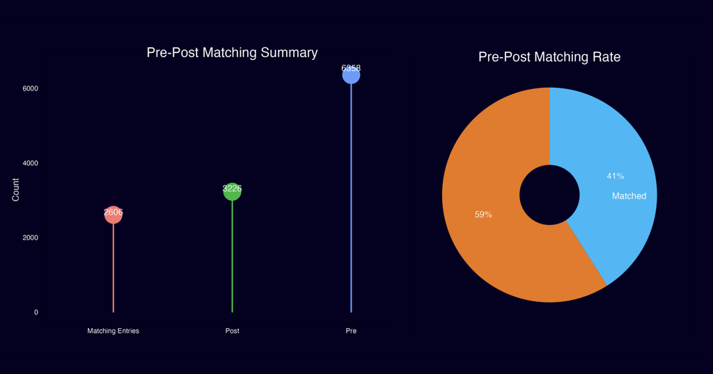

#### 1.3 Encoding categorical varriables to numerical.

A tailored function named map_response was used to address the specific task of encoding categorical variables into numerical representations. This step served as a quality control measure aimed at identifying potential misspelled values that might not be detected by a built-in function. It’s notable that the variable Q8 was excluded from this process due to its pre-existing numerical nature. It’s worth highlighting that this procedure was also used to ensure the accuracy and integrity of the data encoding process, especially in cases where misspelled values could lead to inaccuracies.

```python
#7-point likert scale used
scale = {
    'Strongly disagree': 1,
    'Disagree': 2,
    'Somewhat disagree': 3,
    'Neither agree nor disagree': 4,
    'Somewhat agree': 5,
    'Agree': 6,
    'Strongly agree': 7
}
```

Final observations on data cleaning  
- The ultimate dataset comprised a cumulative count of 2,325 records.  
- De-duplicated dataframes of the cleaned pre and post-survey (for Q5 analysis) and merged datasets were exported as CSV files. These files are accessible in the data_output directory.

### Step 2: Data analysis

The procedural details pertaining to data analysis are expounded upon within the data_analysis rmarkdown or ipynb files. This comprehensive reference is accessible within the code folder. The analysis itself was executed on the refined dataset, wherein diligent data quality control measures were applied in preparation for each analytical procedure. This robust approach ensures the conformity of the dataset with the prerequisites for rigorous analysis.

Following this preparatory phase, the subsequent sections elucidate the methodological aspects and consequential observations for each individual question.

##### Question 5. Summarize the data for each of Q1-8 by reporting the mean response for each question. Please report the summary statistic for anyone who completed either the pre or post survey.

The stipulation necessitates the distinct treatment of pre and post surveys in the context of summarizing mean responses for individual questions. This stems from the inherent distinct nature between the pre and post survey datasets.To execute this analytical procedure, I engage the original pre and post survey data that have undergone cleansing and duplicate removal.

The purpose of this analysis is to compute the mean response value for each individual question. >> The result below represents the mean response values derived from the pre-survey dataset.

```yaml
| Survey |  mean_Q1 |  mean_Q2 |  mean_Q3 |  mean_Q4 |  mean_Q5 |  mean_Q6 |  mean_Q7 |  mean_Q8 |
|:-------|---------:|---------:|---------:|---------:|---------:|---------:|---------:|---------:|
| Pre    | 5.013998 | 4.332652 | 5.046870 | 4.699906 |       NA |       NA |       NA |       NA |
| Post   | 5.229696 | 4.681339 | 5.234346 | 5.035338 | 5.107254 | 5.110043 | 4.980161 | 6.946683 |
```

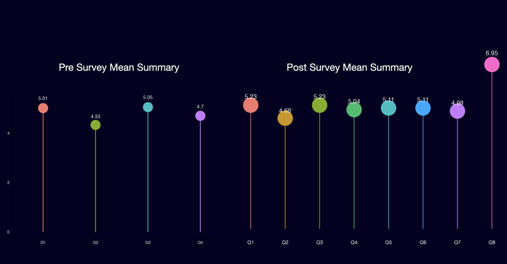

Comparing the mean responses, it’s apparent that the means for Q1 to Q4 have slightly increased from the pre-survey to the post-survey. There is a general tendency towards ‘more agreement’ or positive sentiment among respondents at post.

Observing the specific means for pre surveys, it’s evident that participants’ responses vary across the questions. For instance, in Q1, the mean response is approximately 5.014, implying ‘somewhat agreement’ or a positive sentiment among respondents. In contrast, Q2 exhibits a lower mean response of 4.33, indicating a somewhat less uniform consensus on that particular question. A similar pattern can be observed for Q3 and Q4, with mean response values of approximately 5.047 and 4.700, respectively. But Q4 lends towards a positive sentiment than Q2.

At post, looking at Q1 and Q3 the mean responses of approximately 5.23 reflects a consistent sentiment of ‘somewhat agreement’ or positivity among respondents which alignins with the pre-survey pattern. However, Q2 and Q4 deviate slightly from the pre-survey trend, with mean response values of around 4.68 and 5.04, respectively.

Beyond Q4, the responses reveal distinct trends. In Q5 and Q6, with mean responses of 5.11, participants show a sentiment of ‘somewhat agreement’. Q7 mean response score of 4.980, underscore a positive among participants.

Q8 mean response of 6.95 signifies strong sentiment — a high likelihood that participants would recommend Jack Talks to their friends.

##### Question 6. For individuals with both a pre and post response, compare the individual average change between the pre and post survey for each of Q1-4. Quantify the individual average change and report whether the difference between means is statistically significant.

The purpose of this analysis is to compare the average change between the pre and post survey for Q1 to Q4 and test weather that change is significant. The dataset used for this analysis is the combined, cleaned, unduplicated pre and post dataset.

To test for significance, I used the [**Wilcoxon signed-rank test.**](https://www.statisticshowto.com/probability-and-statistics/statistics-definitions/wilcoxon-signed-rank-test/)

The Wilcoxon signed-rank test is a non-parametric statistical test that is appropriate for comparing paired data when the distribution of the data may not be normal or when the assumptions of parametric tests like the t-test are not met. In this case, we are comparing the individual average change between the pre and post surveys for each question (Q1-4). Here are the reasons why I chose Wilcoxon signed-rank test as a suitable choice:

- Paired Data: The Wilcoxon signed-rank test is designed for paired data, where each individual has two related measurements (pre and post survey).
- Non-Normal Distribution: Data is not normally distributed (non-parametric).
- Ordinal Data: Our data has ordinal response categories (Likert scale), the Wilcoxon test is appropriate because it does not require interval-level data.
- Sensitive to Shifts: The Wilcoxon signed-rank test is sensitive to detecting shifts in the distribution, making it suitable for detecting changes in responses.

The wilcoxon signed-rank test is found in R under the stats library.  
The results of the analysis and test are shown below.

```yaml
| mean_change_Q1 | mean_change_Q2 | mean_change_Q3 | mean_change_Q4 | wilcox_Q1_p-val | wilcox_Q2_p-val | wilcox_Q3_p-val | wilcox_Q4_p-val |
|:---------------|:---------------|:---------------|:---------------|:----------------|:----------------|:----------------|:----------------|
| 0.07053763     | 0.2305376      | 0.1221505      | 0.3195699      | 0.001272983     | 3.802891e-23    | 2.457798e-08    | 1.39444e-45     |
```

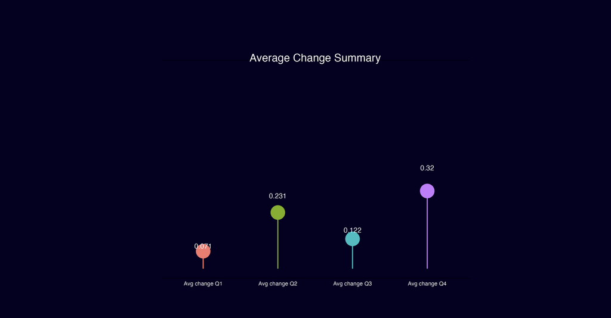

Observations

In the aggregate analysis, statistically significant distinctions emerge in the average change in responses for each question between the pre and post surveys. The notably diminutive p-values underscore the improbability of these disparities arising by random variability, signifying substantial shifts in responses.

Specifically, a notable positive and statistically significant change in mean participants’ responses is observed across all four questions (Q1, Q2, Q3, and Q4) between the pre and post surveys. Among these, Q4 registers the most pronounced alteration in responses, accompanied by the lowest p-value, emphasizing both the substantiality of the observed change and its statistical significance.

## Future work

Delving into Ordinal Regression: Investigate the correlation between predictor variables (change in Q1 to Q4 due to the availability of pre and post-pairs), Q5 to Q7, and the ordinal response Q8 (indicating whether participants would recommend the program). This analysis will offer valuable insights into the influential aspects of the talks that can potentially trigger a snowball effect.